# Babylab analysis - Main Results

M. Rolland

Last modified: 2021-05-31

Remarks:

- How do we deal with associations significant only in the second exposure tertile?
- MnBP significant in T2 and T3 but not preg (because of coding)
- discuss looking time (not great residuals, seemly noisy results and quality of indicator)

# 1 Introduction

# 2 Population description

| name | N | stat |
| --- | --- | --- |
| **Age group** |  |  |
| 5 months | 46 | 17 % |
| 12 months | 67 | 25 % |
| 24 months | 150 | 57 % |
| **Experiment hour** |  |  |
| 8AM | 1 | 0 % |
| 9AM | 82 | 31 % |
| 10AM | 85 | 32 % |
| 11AM | 43 | 16 % |
| 12PM | 2 | 1 % |
| 1PM | 8 | 3 % |
| 2PM | 12 | 5 % |
| 3PM | 18 | 7 % |
| 4PM | 12 | 5 % |
| **Child sex** |  |  |
| Male | 144 | 55 % |
| Female | 119 | 45 % |
| **Parity** |  |  |
| First child | 131 | 50 % |
| Second child | 109 | 41 % |
| Third child or more | 23 | 9 % |
| **Maternal depression during pregnancy** |  |  |
| HAD <= 11 | 186 | 71 % |
| HAD > 11 | 73 | 28 % |
| Missing | 4 | 2 % |
| **Maternal tobacco consumption during pregnancy** |  |  |
| No | 224 | 85 % |
| Yes | 32 | 12 % |
| Missing | 7 | 3 % |
| **Continuous variables (mean(SD))** |  |  |
| Maternal age | 263 | 32.32 (3.92) |
| Breastfeeding duration (days) | 259 | 29.36 (16.23) |

# 3 Exposure description

Description of pregnancy exposure levels per sampling period

|  | N | Second Trimester mean | Second Trimester median | Second Trimester p5 | Second Trimester p95 | Third Trimester mean | Third Trimester median | Third Trimester p5 | Third Trimester p95 |
| --- | --- | --- | --- | --- | --- | --- | --- | --- | --- |
| DEHP_ms | 263 | 0.13 | 0.10 | 0.05 | 0.28 | 0.13 | 0.11 | 0.05 | 0.27 |
| DINCH_ms | 263 | 0.03 | 0.01 | 0.00 | 0.12 | 0.03 | 0.01 | 0.00 | 0.10 |
| DiNP_ms | 263 | 0.08 | 0.04 | 0.02 | 0.23 | 0.07 | 0.04 | 0.02 | 0.18 |
| MBzP | 263 | 6.94 | 4.44 | 1.47 | 18.53 | 7.69 | 3.97 | 1.36 | 23.96 |
| MEP | 263 | 52.97 | 24.14 | 6.45 | 179.06 | 38.65 | 21.29 | 4.62 | 104.28 |
| MiBP | 263 | 19.91 | 14.74 | 6.89 | 49.68 | 17.52 | 14.18 | 5.43 | 43.23 |
| MnBP | 263 | 13.89 | 10.80 | 4.65 | 36.73 | 13.78 | 10.98 | 3.96 | 32.94 |
| ohMPHP | 263 | 1.10 | 0.82 | 0.50 | 2.33 | 1.28 | 0.77 | 0.48 | 2.46 |

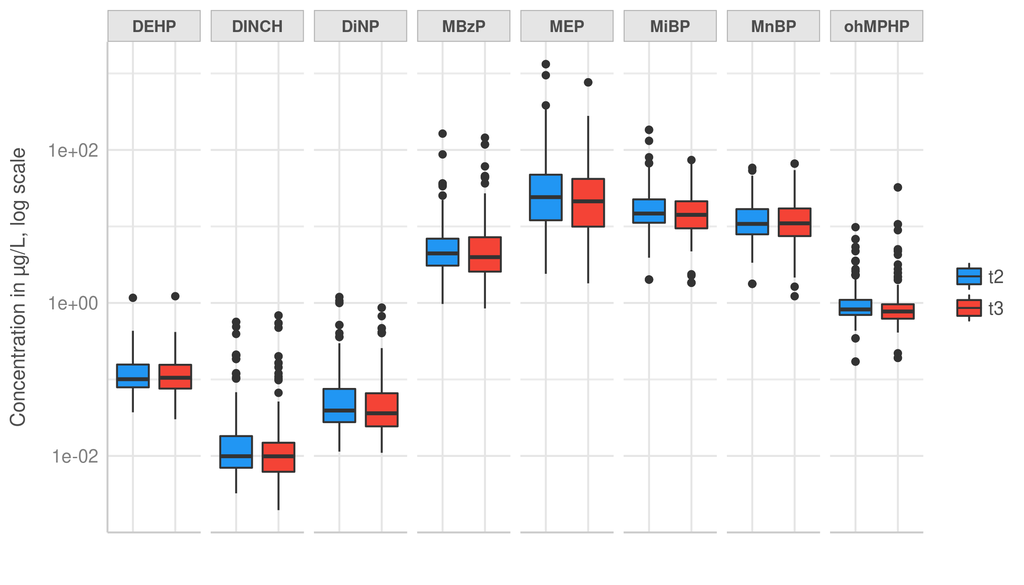

Comparable exposure levels between both sampling periods.

# 4 Outcome description

Description of babylab score distributions per age category

| score | 5 months N | 5 months mean | 5 months median | 5 months p5 | 5 months p95 | 12 months N | 12 months mean | 12 months median | 12 months p5 | 12 months p95 | 24 months N | 24 months mean | 24 months median | 24 months p5 | 24 months p95 |
| --- | --- | --- | --- | --- | --- | --- | --- | --- | --- | --- | --- | --- | --- | --- | --- |
| fix_dur | 46 | 416.56 | 407.00 | 328.35 | 545.55 | 67 | 391.84 | 383.00 | 322.62 | 484.62 | 150 | 358.47 | 352.00 | 285.50 | 450.80 |
| look_t | 46 | 4100.34 | 4185.42 | 3536.86 | 4483.91 | 67 | 3917.54 | 3988.96 | 3266.83 | 4368.14 | 150 | 4141.98 | 4176.50 | 3815.63 | 4386.30 |
| mean_map | 46 | 0.04 | 0.04 | 0.03 | 0.06 | 67 | 0.06 | 0.06 | 0.04 | 0.07 | 150 | 0.06 | 0.06 | 0.04 | 0.07 |
| novelty | 46 | 0.04 | 0.05 | -0.27 | 0.34 | 67 | 0.08 | 0.07 | -0.21 | 0.45 | 150 | 0.10 | 0.10 | -0.17 | 0.35 |
| pct_eyes | 46 | 0.73 | 0.74 | 0.44 | 0.95 | 67 | 0.73 | 0.78 | 0.39 | 0.93 | 150 | 0.68 | 0.73 | 0.30 | 0.91 |
| reac_t | 46 | 464.04 | 442.00 | 340.00 | 628.80 | 67 | 322.97 | 323.50 | 225.45 | 418.97 | 150 | 297.28 | 292.00 | 211.30 | 395.55 |

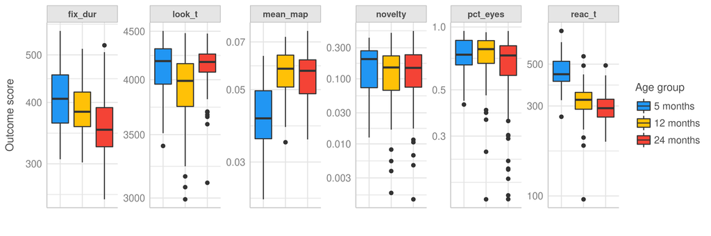

- **Decrease of fixations duration** with increasing age
- **Lower attention times** at 12 months
- **Lower mean maps** at 5 months (means there is more variability in the gaze location from one child to another)
- Comparable times of **reaction to novelty**
- Comparable levels of **eye looking** (maybe lower at 24m, needs formally testing)
- **Reaction times decrease** with increasing age

# 5 Covariate selection

Covariate selection on model without exposure:

$score = age\_cat + ns(exp_h, 4) + tobacco + maternal\_age + child\_sex + had\_cat + education + parity + (1|ident)$

Anova table (Wald p-values) for models without exposure run for each score:

| term | fix_dur | look_t | mean_map | novelty | pct_eyes | reac_t |
| --- | --- | --- | --- | --- | --- | --- |
| ch_age_cat | 0 | 0 | 0 | 0.132 | 0.032 | 0 |
| ns(expe_h, 4) | 0.275 | 0.718 | 0.715 | 0.261 | 0.689 | 0.231 |
| tobacco | 0.111 | 0.863 | 0.627 | 0.702 | 0.703 | 0.459 |
| mo_age | 0.023 | 0.496 | 0.399 | 0.875 | 0.161 | 0.031 |
| sex | 0.656 | 0.035 | 0.11 | 0.92 | 0.606 | 0.043 |
| had_cat | 0.664 | 0.626 | 0.862 | 0.129 | 0.808 | 0.763 |
| edu | 0.605 | 0.236 | 0.695 | 0.262 | 0.729 | 0.755 |
| parity | 0.618 | 0.753 | 0.907 | 0.585 | 0.636 | 0.485 |
| pr_status | 0.241 | 0.45 | 0.999 | 0.72 | 0.972 | 0.467 |
| bf_duration | 0.11 | 0.741 | 0.256 | 0.42 | 0.381 | 0.89 |

- P always > 0.2 for maternal education, professional status and parity, these two variables not included in final models
- no SES variable selected

Final selected variables:

```
## [1] "ch_age_cat"  "tobacco"     "mo_age"      "bf_duration" "sex"         "had_cat"
```

# 6 Note on model diagnostics

All model diagnostics are founs in a separate document `model_diagnostics.html`

# 7 Models without exposure

Regarding model diagnostics:

- Residuals overall OK, maybe not so good for **looking time** and **percent eyes**. We may want to interpret these two indicators with more care.

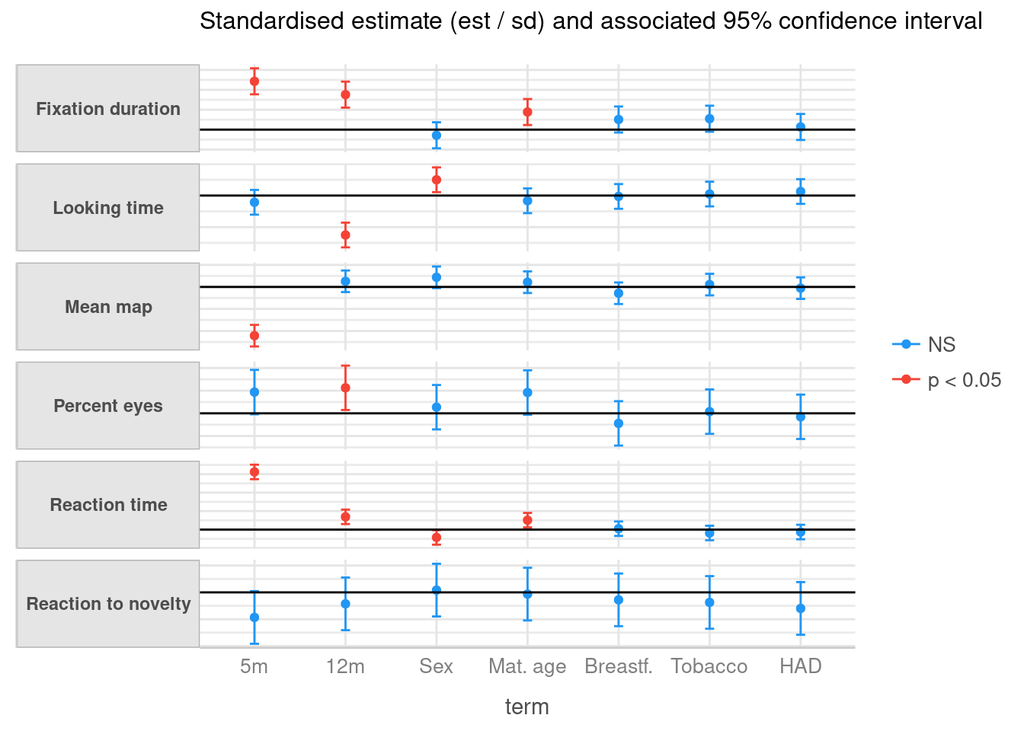

- Confirms relationships with **child age** previously observed in the descriptive boxplots, for all scores except reaction to novelty
- No significant association for **reaction to novelty**
- Associations between **sex and looking time** (higher for girls) and **reaction time** (lower for girls)
- Associations between **maternal age and reaction time** (increases with maternal age) and **fixation duration** (increases with maternal age)
- All associations very similar for reaction time and fixation duration

# 8 Pregnancy mean

## 8.1 Pregnancy mean - relationship shape

Check annex for plots/values.

Suspected associations:

- **Looking time**: MBzP, MEP, MnBP non linear
- **Reaction to novelty**: DEHP and ohMPHP non linear
- **Percent eyes**: DiNP non linear

=> will present tertile models for at least:

- Looking time VS MBzP, MEP, MnBP VS
- Percent eyes VS DiNP

## 8.2 Pregnancy mean - final model

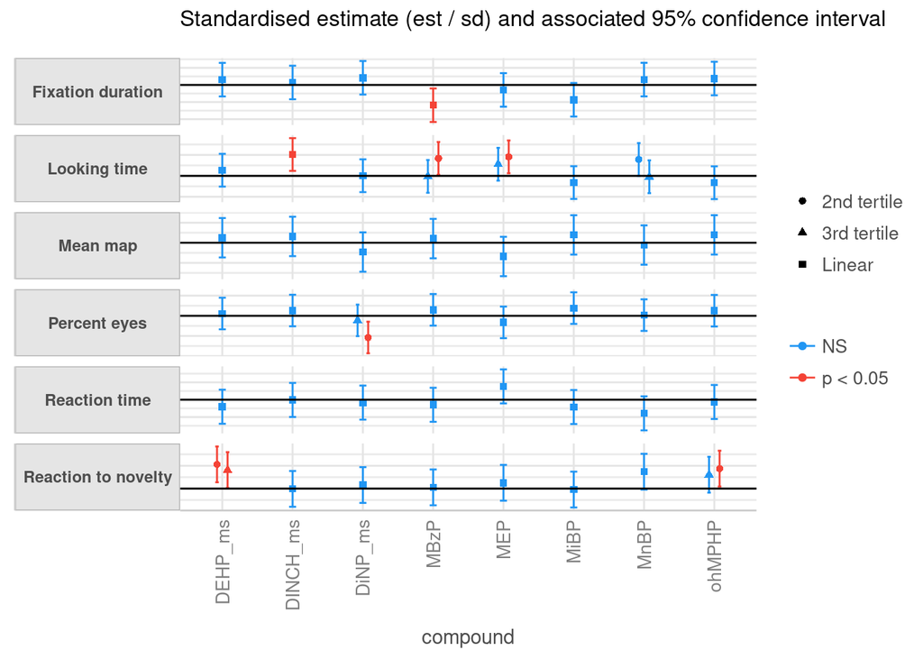

- **Fixation duration**: negative association with **MBzP**
- **Looking time**: positive association with **DINCH**, **MBzP**, **MEP**
- **Percent eyes**: negative association with **DiNP**
- **Reaction to novelty**: positive associations with **DEHP** and **ohMPHP**

=> associations in same direction within scores

# 9 T2 exposure

## 9.1 T2 exposure - relationship shape

Check annex for plots/values.

- **Looking time**: DEHP, MiBP non linear
- **Reaction to novelty**: MnBP non linear
- **Reaction time**: MBzP linear

=> will present tertile models for at least:

- Looking time VS DEHP and MiBP
- Reaction to novelty and MnBP

## 9.2 T2 exposure - final model

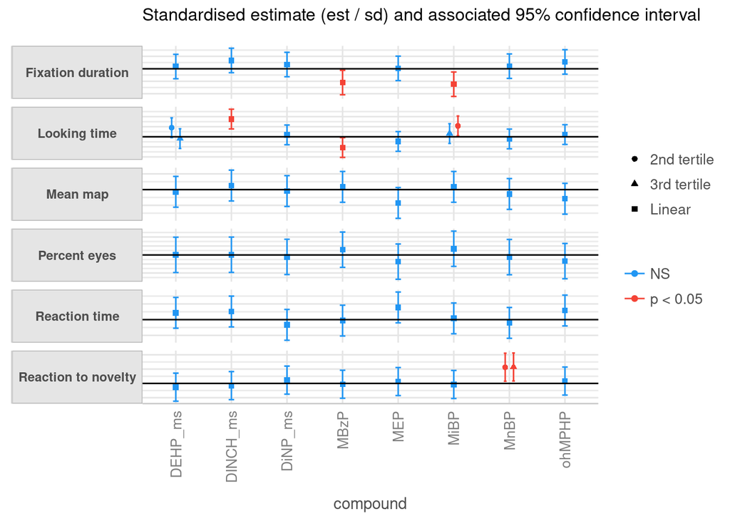

- **Fixation duration**: negative association with **MBzP**, **MiBP**
- **Looking time**: positive association with **DINCH**, **MiBP** and negative association with **MBzP**
- **Reaction to novelty**: positive associations with **MnBP**

# 10 T3 exposure

## 10.1 T3 exposure - relationship shape

Check annex for plots/values.

- **Fixation duration**: MnBP linear
- **Looking time**: MEP, MnBP non linear
- **Mean map**: DiNP linear
- **Reaction to novelty**: MEP, MnBP non linear
- **Reaction time**: DEHP, DiNP non linear

## 10.2 T3 exposure - final model

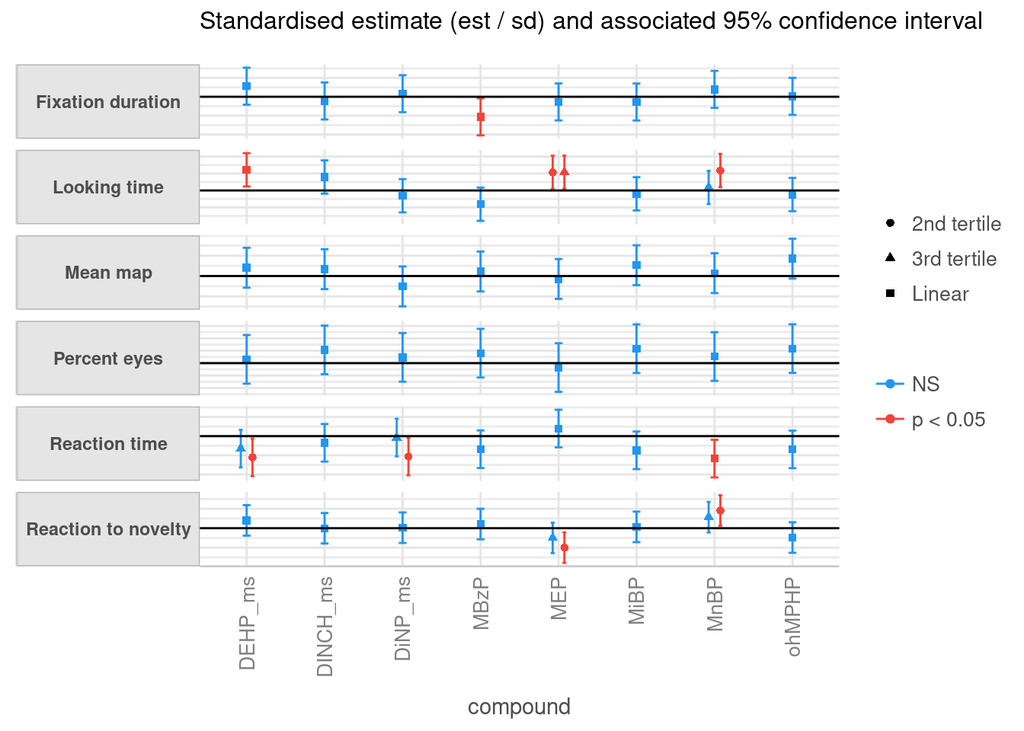

- **Fixation duration**: negative association with **MBzP**
- **Looking time**: positive association with **DEHP**, **MEP** and **MnBP**
- **Reaction time**: negative associations with **DEHP**, **DiNP**, **MnBP**
- **Reaction to novelty**: negative associations with **MEP** positive association with **MnBP**

# 11 All models

Combination of all previous models in one single plot in order to check consistency between T2, T3 and their mean.

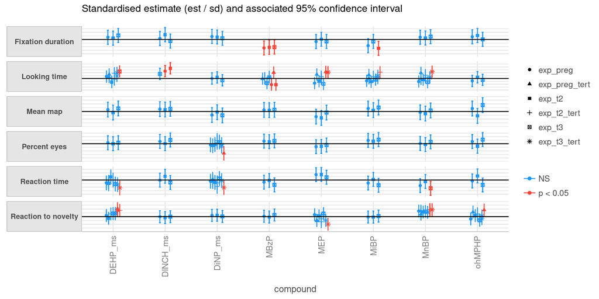

# 12 Annex

## 12.1 Relationship shapes

### 12.1.1 Mean pregnancy exposure

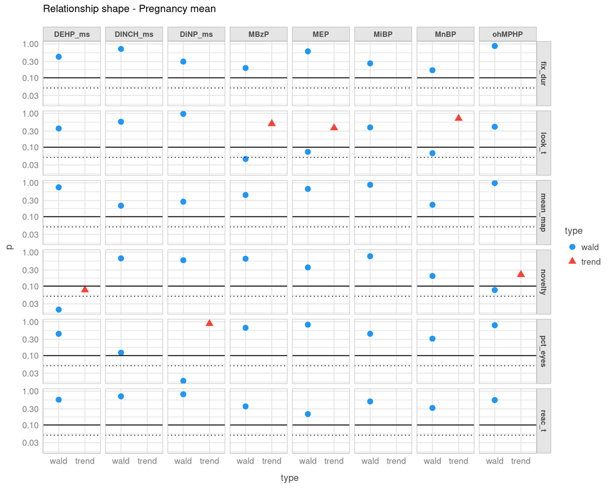

### 12.1.2 T2 exposure

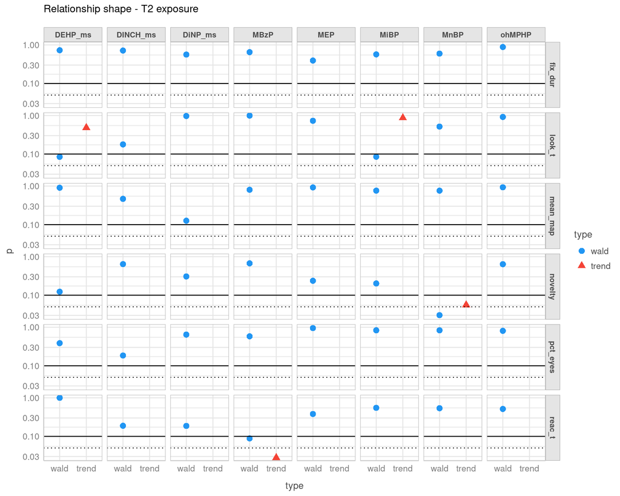

### 12.1.3 T3 exposure

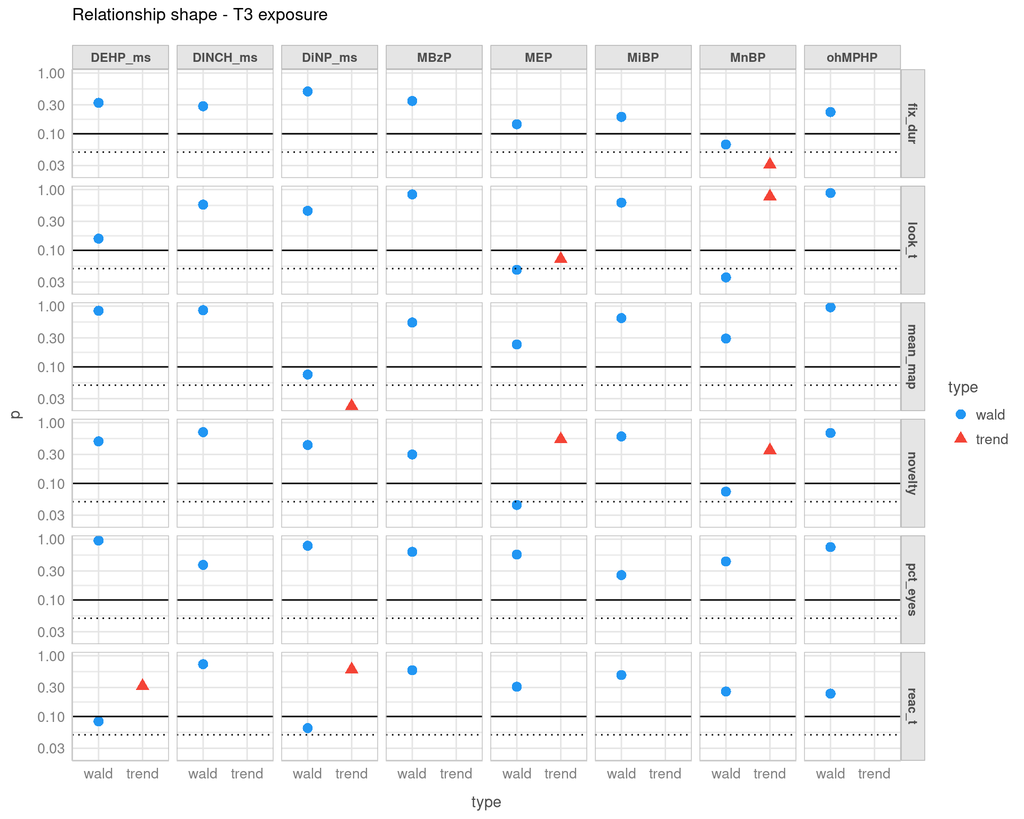

## 12.2 Model outputs

### 12.2.1 Model with no exp

| term | estimate | sd | conf.low | conf.high | p |
| --- | --- | --- | --- | --- | --- |
| **Fixation duration** |  |  |  |  |  |
| (Intercept) | 268.9272592 | 30.1312543 | 209.8710861 | 327.9834324 | 0.0000000 |
| ch_age_cat5 | 58.2150605 | 7.9935874 | 42.5479171 | 73.8822039 | 0.0000000 |
| ch_age_cat12 | 31.9870536 | 6.0632291 | 20.1033430 | 43.8707642 | 0.0000001 |
| tobacco1 | 18.1069473 | 11.0000735 | -3.4528006 | 39.6666952 | 0.0997483 |
| mo_age | 2.4909195 | 0.9374300 | 0.6535904 | 4.3282485 | 0.0078798 |
| bf_duration | 0.3448025 | 0.2260512 | -0.0982496 | 0.7878546 | 0.1271769 |
| sex2 | -6.2433154 | 7.3287471 | -20.6073959 | 8.1207650 | 0.3942729 |
| had_cat>11 | 3.2093450 | 7.9930346 | -12.4567149 | 18.8754049 | 0.6880390 |
| ****Total looking time |  |  |  |  |  |
| (Intercept) | 4219.2007885 | 140.3287627 | 3944.1614676 | 4494.2401093 | 0.0000000 |
| ch_age_cat5 | -48.8643785 | 45.8718266 | -138.7715066 | 41.0427496 | 0.2867686 |
| ch_age_cat12 | -231.6391947 | 37.0371734 | -304.2307205 | -159.0476688 | 0.0000000 |
| tobacco1 | 12.3127957 | 51.2650575 | -88.1648706 | 112.7904620 | 0.8101914 |
| mo_age | -3.5916537 | 4.3562840 | -12.1298134 | 4.9465060 | 0.4096689 |
| bf_duration | -0.1465696 | 1.0450876 | -2.1949036 | 1.9017644 | 0.8884654 |
| sex2 | 84.8201292 | 33.9326005 | 18.3134544 | 151.3268040 | 0.0124311 |
| had_cat>11 | 24.0549847 | 37.5580555 | -49.5574513 | 97.6674208 | 0.5218640 |
| **Mean map** |  |  |  |  |  |
| (Intercept) | 0.0514957 | 0.0052376 | 0.0412302 | 0.0617612 | 0.0000000 |
| ch_age_cat5 | -0.0134132 | 0.0015150 | -0.0163826 | -0.0104438 | 0.0000000 |
| ch_age_cat12 | 0.0012062 | 0.0011778 | -0.0011022 | 0.0035146 | 0.3057839 |
| tobacco1 | 0.0008125 | 0.0019119 | -0.0029348 | 0.0045598 | 0.6708601 |
| mo_age | 0.0001405 | 0.0001628 | -0.0001786 | 0.0004596 | 0.3880322 |
| bf_duration | -0.0000449 | 0.0000392 | -0.0001217 | 0.0000320 | 0.2525567 |
| sex2 | 0.0022264 | 0.0012715 | -0.0002656 | 0.0047184 | 0.0799359 |
| had_cat>11 | -0.0003017 | 0.0013928 | -0.0030315 | 0.0024281 | 0.8285102 |
| **Reaction to novelty** |  |  |  |  |  |
| (Intercept) | 0.1373127 | 0.0975048 | -0.0537932 | 0.3284187 | 0.1590524 |
| ch_age_cat5 | -0.0593716 | 0.0318231 | -0.1217436 | 0.0030005 | 0.0620864 |
| ch_age_cat12 | -0.0219307 | 0.0256815 | -0.0722655 | 0.0284041 | 0.3931326 |
| tobacco1 | -0.0266699 | 0.0356196 | -0.0964831 | 0.0431432 | 0.4540118 |
| mo_age | -0.0003861 | 0.0030269 | -0.0063187 | 0.0055466 | 0.8985049 |
| bf_duration | -0.0004049 | 0.0007262 | -0.0018283 | 0.0010184 | 0.5771159 |
| sex2 | 0.0039485 | 0.0235789 | -0.0422654 | 0.0501624 | 0.8670087 |
| had_cat>11 | -0.0311865 | 0.0260936 | -0.0823289 | 0.0199560 | 0.2320180 |
| **Percent eyes** |  |  |  |  |  |
| (Intercept) | 0.5079373 | 0.1029815 | 0.3060973 | 0.7097773 | 0.0000008 |
| ch_age_cat5 | 0.0530385 | 0.0282840 | -0.0023971 | 0.1084741 | 0.0607633 |
| ch_age_cat12 | 0.0488362 | 0.0216590 | 0.0063854 | 0.0912871 | 0.0241473 |
| tobacco1 | 0.0055934 | 0.0375936 | -0.0680887 | 0.0792756 | 0.8817221 |
| mo_age | 0.0058834 | 0.0032028 | -0.0003939 | 0.0121607 | 0.0662125 |
| bf_duration | -0.0006847 | 0.0007720 | -0.0021977 | 0.0008283 | 0.3751177 |
| sex2 | 0.0135622 | 0.0250301 | -0.0354959 | 0.0626202 | 0.5879330 |
| had_cat>11 | -0.0083767 | 0.0273408 | -0.0619636 | 0.0452103 | 0.7593155 |
| **Reaction time** |  |  |  |  |  |
| (Intercept) | 207.2206176 | 38.3365527 | 132.0823550 | 282.3588801 | 0.0000001 |
| ch_age_cat5 | 170.9457647 | 10.9596646 | 149.4652168 | 192.4263126 | 0.0000000 |
| ch_age_cat12 | 29.7136417 | 8.6151922 | 12.8281754 | 46.5991081 | 0.0005627 |
| tobacco1 | -12.5478068 | 13.6353280 | -39.2725586 | 14.1769451 | 0.3574461 |
| mo_age | 3.0519767 | 1.1987910 | 0.7023895 | 5.4015639 | 0.0109003 |
| bf_duration | 0.0673437 | 0.2824979 | -0.4863421 | 0.6210295 | 0.8115814 |
| sex2 | -19.4571222 | 9.1787951 | -37.4472301 | -1.4670144 | 0.0340237 |
| had_cat>11 | -6.6717237 | 10.0565056 | -26.3821125 | 13.0386651 | 0.5070593 |

### 12.2.2 Linear models

#### 12.2.2.1 Mean pregnancy exposure

| outcome | compound | term | estimate | sd | conf.low | conf.high | p |
| --- | --- | --- | --- | --- | --- | --- | --- |
| fix_dur | DEHP_ms | (Intercept) | 267.3031557 | 30.1626633 | 208.1854219 | 326.4208895 | 0.0000000 |
| fix_dur | DEHP_ms | exp_val | 36.3830076 | 58.6742546 | -78.6164181 | 151.3824334 | 0.5352020 |
| fix_dur | DEHP_ms | ch_age_cat5 | 58.0962861 | 8.0262213 | 42.3651814 | 73.8273908 | 0.0000000 |
| fix_dur | DEHP_ms | ch_age_cat12 | 32.0184054 | 6.0797304 | 20.1023527 | 43.9344580 | 0.0000001 |
| fix_dur | DEHP_ms | tobacco1 | 18.4201007 | 11.0049913 | -3.1492859 | 39.9894873 | 0.0941709 |
| fix_dur | DEHP_ms | mo_age | 2.4246105 | 0.9490012 | 0.5646023 | 4.2846188 | 0.0106216 |
| fix_dur | DEHP_ms | bf_duration | 0.3071386 | 0.2281374 | -0.1400025 | 0.7542797 | 0.1782097 |
| fix_dur | DEHP_ms | sex2 | -5.9469502 | 7.3539621 | -20.3604511 | 8.4665506 | 0.4187033 |
| fix_dur | DEHP_ms | had_cat>11 | 3.0457883 | 8.0658728 | -12.7630319 | 18.8546085 | 0.7057172 |
| fix_dur | DINCH_ms | (Intercept) | 267.6316994 | 30.2221520 | 208.3973699 | 326.8660288 | 0.0000000 |
| fix_dur | DINCH_ms | exp_val | 17.6277450 | 61.3167150 | -102.5508080 | 137.8062980 | 0.7737396 |
| fix_dur | DINCH_ms | ch_age_cat5 | 58.5036604 | 7.9966315 | 42.8305507 | 74.1767702 | 0.0000000 |
| fix_dur | DINCH_ms | ch_age_cat12 | 32.1446726 | 6.0663977 | 20.2547517 | 44.0345936 | 0.0000001 |
| fix_dur | DINCH_ms | tobacco1 | 18.4761814 | 11.0231408 | -3.1287775 | 40.0811404 | 0.0937134 |
| fix_dur | DINCH_ms | mo_age | 2.5096851 | 0.9394067 | 0.6684817 | 4.3508885 | 0.0075499 |
| fix_dur | DINCH_ms | bf_duration | 0.3206847 | 0.2272795 | -0.1247750 | 0.7661444 | 0.1582534 |
| fix_dur | DINCH_ms | sex2 | -5.4574372 | 7.4015644 | -19.9642367 | 9.0493624 | 0.4609183 |
| fix_dur | DINCH_ms | had_cat>11 | 3.9444022 | 8.0693813 | -11.8712945 | 19.7600988 | 0.6249755 |
| fix_dur | DiNP_ms | (Intercept) | 262.9574719 | 30.7140509 | 202.7590382 | 323.1559056 | 0.0000000 |
| fix_dur | DiNP_ms | exp_val | 63.1121121 | 75.4864019 | -84.8385168 | 211.0627411 | 0.4031141 |
| fix_dur | DiNP_ms | ch_age_cat5 | 58.2891949 | 7.9997258 | 42.6100204 | 73.9683694 | 0.0000000 |
| fix_dur | DiNP_ms | ch_age_cat12 | 32.2735809 | 6.0668329 | 20.3828069 | 44.1643550 | 0.0000001 |
| fix_dur | DiNP_ms | tobacco1 | 17.6727225 | 11.0381416 | -3.9616374 | 39.3070825 | 0.1093637 |
| fix_dur | DiNP_ms | mo_age | 2.5664185 | 0.9390447 | 0.7259247 | 4.4069123 | 0.0062758 |
| fix_dur | DiNP_ms | bf_duration | 0.3278360 | 0.2267479 | -0.1165817 | 0.7722537 | 0.1482285 |
| fix_dur | DiNP_ms | sex2 | -6.0085076 | 7.3472588 | -20.4088702 | 8.3918550 | 0.4134777 |
| fix_dur | DiNP_ms | had_cat>11 | 3.3173355 | 8.0082740 | -12.3785931 | 19.0132641 | 0.6786994 |
| fix_dur | MBzP | (Intercept) | 262.4866821 | 29.8101062 | 204.0599475 | 320.9134167 | 0.0000000 |
| fix_dur | MBzP | exp_val | -0.6720120 | 0.2838034 | -1.2282565 | -0.1157674 | 0.0178904 |
| fix_dur | MBzP | ch_age_cat5 | 58.9368753 | 7.9492668 | 43.3565986 | 74.5171521 | 0.0000000 |

[output cut: 402 more lines]

#### 12.2.2.2 T2 exposure

| outcome | compound | term | estimate | sd | conf.low | conf.high | p |
| --- | --- | --- | --- | --- | --- | --- | --- |
| fix_dur | DEHP_ms | (Intercept) | 269.3064463 | 30.2133559 | 210.0893570 | 328.5235356 | 0.0000000 |
| fix_dur | DEHP_ms | exp_val | 13.2898689 | 36.6003770 | -58.4455518 | 85.0252896 | 0.7165246 |
| fix_dur | DEHP_ms | ch_age_cat5 | 57.8343937 | 8.0720927 | 42.0133828 | 73.6554047 | 0.0000000 |
| fix_dur | DEHP_ms | ch_age_cat12 | 31.9725890 | 6.0698796 | 20.0758437 | 43.8693343 | 0.0000001 |
| fix_dur | DEHP_ms | tobacco1 | 18.4141355 | 11.0568219 | -3.2568373 | 40.0851082 | 0.0958311 |
| fix_dur | DEHP_ms | mo_age | 2.4289240 | 0.9546865 | 0.5577728 | 4.3000751 | 0.0109525 |
| fix_dur | DEHP_ms | bf_duration | 0.3394678 | 0.2270264 | -0.1054957 | 0.7844313 | 0.1348416 |
| fix_dur | DEHP_ms | sex2 | -6.0673066 | 7.3606209 | -20.4938585 | 8.3592453 | 0.4097732 |
| fix_dur | DEHP_ms | had_cat>11 | 3.1526618 | 8.0118725 | -12.5503198 | 18.8556435 | 0.6939511 |
| fix_dur | DINCH_ms | (Intercept) | 267.6532072 | 30.1451787 | 208.5697427 | 326.7366717 | 0.0000000 |
| fix_dur | DINCH_ms | exp_val | 71.1014307 | 53.2209232 | -33.2096619 | 175.4125234 | 0.1815599 |
| fix_dur | DINCH_ms | ch_age_cat5 | 57.8170870 | 7.9728736 | 42.1905420 | 73.4436321 | 0.0000000 |
| fix_dur | DINCH_ms | ch_age_cat12 | 31.5402924 | 6.0458329 | 19.6906777 | 43.3899072 | 0.0000002 |
| fix_dur | DINCH_ms | tobacco1 | 17.3568377 | 11.0132548 | -4.2287450 | 38.9424204 | 0.1150269 |
| fix_dur | DINCH_ms | mo_age | 2.4661710 | 0.9375482 | 0.6286102 | 4.3037317 | 0.0085273 |
| fix_dur | DINCH_ms | bf_duration | 0.3278954 | 0.2264069 | -0.1158539 | 0.7716448 | 0.1475451 |
| fix_dur | DINCH_ms | sex2 | -5.2491758 | 7.3660948 | -19.6864563 | 9.1881048 | 0.4760852 |
| fix_dur | DINCH_ms | had_cat>11 | 4.5110281 | 8.0502690 | -11.2672093 | 20.2892655 | 0.5752357 |
| fix_dur | DiNP_ms | (Intercept) | 266.2710781 | 30.4192153 | 206.6505117 | 325.8916446 | 0.0000000 |
| fix_dur | DiNP_ms | exp_val | 17.3965433 | 25.4045569 | -32.3954733 | 67.1885599 | 0.4934825 |
| fix_dur | DiNP_ms | ch_age_cat5 | 58.0431060 | 8.0044251 | 42.3547212 | 73.7314909 | 0.0000000 |
| fix_dur | DiNP_ms | ch_age_cat12 | 31.9046545 | 6.0688637 | 20.0099002 | 43.7994088 | 0.0000001 |
| fix_dur | DiNP_ms | tobacco1 | 17.7025395 | 11.0298288 | -3.9155277 | 39.3206068 | 0.1085005 |
| fix_dur | DiNP_ms | mo_age | 2.5400546 | 0.9413852 | 0.6949736 | 4.3851356 | 0.0069714 |
| fix_dur | DiNP_ms | bf_duration | 0.3447107 | 0.2263411 | -0.0989097 | 0.7883311 | 0.1277662 |
| fix_dur | DiNP_ms | sex2 | -6.3260976 | 7.3391411 | -20.7105498 | 8.0583546 | 0.3887057 |
| fix_dur | DiNP_ms | had_cat>11 | 2.5565949 | 8.0598962 | -13.2405113 | 18.3537010 | 0.7510922 |
| fix_dur | MBzP | (Intercept) | 265.5211030 | 29.8515481 | 207.0131438 | 324.0290621 | 0.0000000 |
| fix_dur | MBzP | exp_val | -0.5953113 | 0.2698906 | -1.1242872 | -0.0663355 | 0.0274015 |
| fix_dur | MBzP | ch_age_cat5 | 58.4744793 | 7.9573538 | 42.8783525 | 74.0706062 | 0.0000000 |

[output cut: 402 more lines]

#### 12.2.2.3 T3 exposure

| outcome | compound | term | estimate | sd | conf.low | conf.high | p |
| --- | --- | --- | --- | --- | --- | --- | --- |
| fix_dur | DEHP_ms | (Intercept) | 265.8484965 | 30.1153793 | 206.8234378 | 324.8735552 | 0.0000000 |
| fix_dur | DEHP_ms | exp_val | 39.9250063 | 35.6610827 | -29.9694315 | 109.8194441 | 0.2628979 |
| fix_dur | DEHP_ms | ch_age_cat5 | 58.4870263 | 7.9960951 | 42.8149679 | 74.1590847 | 0.0000000 |
| fix_dur | DEHP_ms | ch_age_cat12 | 31.5846758 | 6.1003248 | 19.6282589 | 43.5410928 | 0.0000002 |
| fix_dur | DEHP_ms | tobacco1 | 17.7183715 | 10.9940902 | -3.8296492 | 39.2663923 | 0.1070432 |
| fix_dur | DEHP_ms | mo_age | 2.4808387 | 0.9355398 | 0.6472145 | 4.3144630 | 0.0080070 |
| fix_dur | DEHP_ms | bf_duration | 0.2922220 | 0.2277461 | -0.1541522 | 0.7385961 | 0.1994556 |
| fix_dur | DEHP_ms | sex2 | -6.6320590 | 7.3689841 | -21.0750025 | 7.8108846 | 0.3681222 |
| fix_dur | DEHP_ms | had_cat>11 | 2.3236494 | 8.0696540 | -13.4925817 | 18.1398805 | 0.7733857 |
| fix_dur | DINCH_ms | (Intercept) | 268.5242152 | 30.1879598 | 209.3569012 | 327.6915291 | 0.0000000 |
| fix_dur | DINCH_ms | exp_val | -20.5730948 | 46.0856953 | -110.8993977 | 69.7532081 | 0.6553014 |
| fix_dur | DINCH_ms | ch_age_cat5 | 58.3486756 | 8.0074036 | 42.6544529 | 74.0428983 | 0.0000000 |
| fix_dur | DINCH_ms | ch_age_cat12 | 32.2857142 | 6.0708769 | 20.3870141 | 44.1844142 | 0.0000001 |
| fix_dur | DINCH_ms | tobacco1 | 18.2901288 | 11.0193373 | -3.3073754 | 39.8876330 | 0.0969504 |
| fix_dur | DINCH_ms | mo_age | 2.5249031 | 0.9386132 | 0.6852550 | 4.3645512 | 0.0071444 |
| fix_dur | DINCH_ms | bf_duration | 0.3203797 | 0.2270149 | -0.1245613 | 0.7653207 | 0.1581645 |
| fix_dur | DINCH_ms | sex2 | -5.9556014 | 7.3709780 | -20.4024528 | 8.4912500 | 0.4191022 |
| fix_dur | DINCH_ms | had_cat>11 | 3.3089906 | 8.0493601 | -12.4674652 | 19.0854464 | 0.6810084 |
| fix_dur | DiNP_ms | (Intercept) | 267.1822205 | 30.2860636 | 207.8226266 | 326.5418144 | 0.0000000 |
| fix_dur | DiNP_ms | exp_val | 11.3466579 | 34.9103749 | -57.0764195 | 79.7697354 | 0.7451640 |
| fix_dur | DiNP_ms | ch_age_cat5 | 58.4769860 | 7.9992193 | 42.7988044 | 74.1551677 | 0.0000000 |
| fix_dur | DiNP_ms | ch_age_cat12 | 32.2267167 | 6.0666333 | 20.3363339 | 44.1170994 | 0.0000001 |
| fix_dur | DiNP_ms | tobacco1 | 18.4326297 | 11.0191218 | -3.1644522 | 40.0297117 | 0.0943695 |
| fix_dur | DiNP_ms | mo_age | 2.5184780 | 0.9389743 | 0.6781223 | 4.3588338 | 0.0073149 |
| fix_dur | DiNP_ms | bf_duration | 0.3230650 | 0.2271149 | -0.1220721 | 0.7682021 | 0.1548888 |
| fix_dur | DiNP_ms | sex2 | -5.8872164 | 7.3760501 | -20.3440089 | 8.5695762 | 0.4247817 |
| fix_dur | DiNP_ms | had_cat>11 | 3.6888005 | 8.0126459 | -12.0156970 | 19.3932979 | 0.6452490 |
| fix_dur | MBzP | (Intercept) | 260.9272659 | 30.0088996 | 202.1109034 | 319.7436284 | 0.0000000 |
| fix_dur | MBzP | exp_val | -0.5176501 | 0.2435611 | -0.9950211 | -0.0402790 | 0.0335583 |
| fix_dur | MBzP | ch_age_cat5 | 59.1407670 | 7.9582225 | 43.5429376 | 74.7385964 | 0.0000000 |

[output cut: 402 more lines]

### 12.2.3 Tertile models

#### 12.2.3.1 Mean pregnancy exposure

| compound | estimate | sd | conf.low | conf.high | p | model |
| --- | --- | --- | --- | --- | --- | --- |
| **Fixation duration** |  |  |  |  |  |  |
| DEHP_ms | 10.2399809 | 8.8165095 | -7.0400601 | 27.5200220 | 0.2454568 | tertile |
| DEHP_ms | 10.0427413 | 9.0607583 | -7.7160186 | 27.8015012 | 0.2676988 | tertile |
| DINCH_ms | -6.7315667 | 8.8538320 | -24.0847585 | 10.6216251 | 0.4470754 | tertile |
| DINCH_ms | -0.7647226 | 9.2254147 | -18.8462031 | 17.3167579 | 0.9339366 | tertile |
| DiNP_ms | 8.9728883 | 9.0463986 | -8.7577272 | 26.7035038 | 0.3212590 | tertile |
| DiNP_ms | 13.8502082 | 9.0685705 | -3.9238634 | 31.6242797 | 0.1266924 | tertile |
| MBzP | 11.3746498 | 9.0992770 | -6.4596053 | 29.2089050 | 0.2112773 | tertile |
| MBzP | -4.3568739 | 9.0599292 | -22.1140087 | 13.4002610 | 0.6305912 | tertile |
| **Total looking time** |  |  |  |  |  |  |
| MEP | 5.7186588 | 8.9881945 | -11.8978788 | 23.3351963 | 0.5246193 | tertile |
| MEP | 8.8711581 | 8.9717094 | -8.7130692 | 26.4553855 | 0.3227647 | tertile |
| MiBP | 12.3471320 | 8.5308318 | -4.3729910 | 29.0672551 | 0.1477979 | tertile |
| MiBP | 0.2751021 | 9.1679101 | -17.6936714 | 18.2438757 | 0.9760614 | tertile |
| MnBP | 16.4984137 | 8.7318807 | -0.6157581 | 33.6125855 | 0.0588321 | tertile |
| MnBP | 9.3454034 | 9.5709481 | -9.4133101 | 28.1041170 | 0.3288492 | tertile |
| ohMPHP | 2.9600923 | 8.6078725 | -13.9110278 | 19.8312124 | 0.7309350 | tertile |
| ohMPHP | 4.7441006 | 9.2297599 | -13.3458963 | 22.8340975 | 0.6072517 | tertile |
| **Mean map** |  |  |  |  |  |  |
| DEHP_ms | 57.8011071 | 40.7202219 | -22.0090613 | 137.6112755 | 0.1557622 | tertile |
| DEHP_ms | 20.7236127 | 41.9495266 | -61.4959486 | 102.9431740 | 0.6212970 | tertile |
| DINCH_ms | -9.0245184 | 41.2349810 | -89.8435962 | 71.7945593 | 0.8267623 | tertile |
| DINCH_ms | 34.9256774 | 42.5859161 | -48.5411844 | 118.3925391 | 0.4121462 | tertile |
| DiNP_ms | -7.5416188 | 42.2763281 | -90.4016992 | 75.3184616 | 0.8584177 | tertile |
| DiNP_ms | -10.8729858 | 42.6189298 | -94.4045532 | 72.6585816 | 0.7986296 | tertile |
| MBzP | 87.0950276 | 41.7525255 | 5.2615815 | 168.9284738 | 0.0369802 | tertile |
| MBzP | -2.8583885 | 41.7888100 | -84.7629510 | 79.0461741 | 0.9454666 | tertile |
| **Reaction to novelty** |  |  |  |  |  |  |
| MEP | 93.5036042 | 41.2009673 | 12.7511920 | 174.2560163 | 0.0232409 | tertile |
| MEP | 56.7146599 | 40.8930399 | -23.4342254 | 136.8635452 | 0.1654715 | tertile |

[output cut: 72 more lines]

#### 12.2.3.2 T2 exposure

| compound | estimate | sd | conf.low | conf.high | p | model |
| --- | --- | --- | --- | --- | --- | --- |
| **Fixation duration** |  |  |  |  |  |  |
| DEHP_ms | -5.3819363 | 8.6439089 | -22.3236864 | 11.5598138 | 0.5335293 | tertile |
| DEHP_ms | 8.2526054 | 9.1544030 | -9.6896947 | 26.1949055 | 0.3673277 | tertile |
| DINCH_ms | 13.2173072 | 8.9454815 | -4.3155144 | 30.7501289 | 0.1395309 | tertile |
| DINCH_ms | 11.1769087 | 9.1150079 | -6.6881785 | 29.0419960 | 0.2201199 | tertile |
| DiNP_ms | 10.4405020 | 8.8557961 | -6.9165394 | 27.7975435 | 0.2384198 | tertile |
| DiNP_ms | 4.5413133 | 8.9199153 | -12.9413993 | 22.0240260 | 0.6106676 | tertile |
| MBzP | -1.4039805 | 9.2333288 | -19.5009723 | 16.6930113 | 0.8791430 | tertile |
| MBzP | -11.9547808 | 8.9900032 | -29.5748633 | 5.6653017 | 0.1835888 | tertile |
| **Total looking time** |  |  |  |  |  |  |
| MEP | 13.2949469 | 8.9602990 | -4.2669165 | 30.8568103 | 0.1378722 | tertile |
| MEP | 17.0906323 | 9.1018559 | -0.7486774 | 34.9299420 | 0.0604211 | tertile |
| MiBP | 15.8656214 | 8.7464212 | -1.2770493 | 33.0082920 | 0.0696845 | tertile |
| MiBP | 6.6781791 | 9.1085869 | -11.1743233 | 24.5306814 | 0.4634523 | tertile |
| MnBP | 13.6896351 | 9.1021886 | -4.1503266 | 31.5295969 | 0.1325830 | tertile |
| MnBP | 21.4552178 | 9.3160310 | 3.1961326 | 39.7143031 | 0.0212764 | tertile |
| ohMPHP | -11.3430084 | 8.5564678 | -28.1133771 | 5.4273602 | 0.1849507 | tertile |
| ohMPHP | 3.8225274 | 9.1153428 | -14.0432161 | 21.6882709 | 0.6749597 | tertile |
| **Mean map** |  |  |  |  |  |  |
| DEHP_ms | 35.0738842 | 39.5002568 | -42.3451966 | 112.4929650 | 0.3745727 | tertile |
| DEHP_ms | 82.2344969 | 42.6319497 | -1.3225891 | 165.7915828 | 0.0537382 | tertile |
| DINCH_ms | -24.7012585 | 42.0219770 | -107.0628199 | 57.6603030 | 0.5566547 | tertile |
| DINCH_ms | 20.6467616 | 42.6677939 | -62.9805777 | 104.2741010 | 0.6284599 | tertile |
| DiNP_ms | 27.6723645 | 41.4721476 | -53.6115511 | 108.9562801 | 0.5046113 | tertile |
| DiNP_ms | -24.8957741 | 41.4916410 | -106.2178960 | 56.4263479 | 0.5484936 | tertile |
| MBzP | 26.3815688 | 43.4110815 | -58.7025874 | 111.4657250 | 0.5433765 | tertile |
| MBzP | 13.7222599 | 42.3208360 | -69.2250543 | 96.6695742 | 0.7457536 | tertile |
| **Reaction to novelty** |  |  |  |  |  |  |
| MEP | 88.7236262 | 41.5199747 | 7.3459712 | 170.1012811 | 0.0326069 | tertile |
| MEP | 90.3322961 | 42.0319580 | 7.9511722 | 172.7134199 | 0.0316238 | tertile |

[output cut: 72 more lines]

#### 12.2.3.3 T3 exposure

[output not shown]

[output cut: 72 more lines]